# H4H SADC Livestock Emissions Reduction Estimation

Ruan de Wet

02/04/2020

## Objective

This analysis should clip, wrangle and process the [FAO Cattle data](http://www.fao.org/livestock-systems/global-distributions/cattle/en/) required for the H4H SADC Livestock Emissions project.

The countries of interest include all non-SID SADC countries. Or those that have an appreciable number of cattle. There may be cause to include something about the sheep as well.

*One red flag to note: Y has yet to secure funding for this study. X is paying half the bill, so I am proceeding with the analysis.*

## Approach

I’m using the distributions that were modelled using the dasymetric method, because I’m wanting to extract the estimated cattle numbers in spatially explicit areas (defined by the communal/commercial tenure maps and the FMD zones).

The land tenure and FMD zone shapefiles are to be provided by Jacques van Rooyen.

## Analysis

### Project Setup

```r
library("sp")
library("sf")
library("tmap")
library("rgeos")
library("rgdal")
library("raster")
library("rnaturalearth")
library("feather")

library(RColorBrewer)
library(viridisLite)

library("ggplot2")
library("tidyr")
library("dplyr")
library("stringr")

library("readxl")
library("readr")

 rm(list = ls())

today = Sys.Date() %>%
  format("%y%m%d_")

st_plot = function(x, ...) {x %>% st_geometry() %>% plot(...)}
```

### Define the project extent

First step is to define the project extent (i.e. the countries to be included).

22/04/20: We have since decided to exclude the DRC. Removing from iso_aoi data frame.

```r
# Paths
dsn_data = "G:/Ruan/R/_Reference Data/"

# Metadata of consequence
countries_aoi = read_csv("Data/countries_sadc.csv") %>% filter(SID != TRUE)
iso_all = read_excel(paste0(dsn_data, "iso_countries.xlsx"))

# Filter down to area of interest (countries to be included)
iso_aoi = iso_all %>%
  filter(Country %in% countries_aoi$Country)

# Not all countries were identified perfectly. The DRC and Tanzania were missed. The following code picks them out and adds them to the iso_aoi dataframe.

iso_add = iso_all %>%
  filter(str_detect(Country, "Congo") | str_detect(Country, "Tanzania"),
         ISO_3 != "COG")

iso_aoi = rbind(iso_aoi, iso_add) %>%
  unique() %>%
  filter(ISO_3 != "COD") # Exclude the DRC from the AOI.
```

With the ISO codes, we can easily specify the countries that are included in the study. They are loaded in the next chunk from the `rnaturalearth` package.

```r
# Define boundary box for AOI (because there are South African Islands far South)
bound_aoi = ne_countries(continent = "africa", scale = "small",
                        returnclass = "sf", type = "sovereignty") %>%
  filter(sov_a3 %in% iso_aoi$ISO_3) %>%
  st_buffer(dist = 1) %>%
  st_union() %>%
  st_make_grid(n = 1) %>%
    st_as_sf()

bound_bord = ne_countries(continent = "africa", scale = "small",
                        returnclass = "sf", type = "sovereignty") %>%
  st_crop(bound_aoi) %>%
  st_buffer(dist = 0.01) %>%
  st_union()


# Load the country borders of interest
bord_sadc = ne_countries(continent = "africa", scale = "medium",
                        returnclass = "sf", type = "countries") %>%
  filter(sov_a3 %in% iso_aoi$ISO_3)

# Filter borders to boundary
bord_aoi = st_intersection(bound_aoi, bord_sadc)
bord_aoi_union = bord_aoi %>% st_buffer(0.01) %>% st_union() %>% st_as_sf()

bord_naoi = ne_countries(continent = "africa", scale = "medium",
                        returnclass = "sf", type = "countries") %>%
  filter(!sov_a3 %in% bord_aoi$sov_a3) %>%
  st_intersection(bound_aoi)

# qtm(bord_aoi)
# qtm(bord_aoi_union)

bord_aoi_union %>%
  st_buffer(1) %>%
  st_bbox()
```

```
FALSE        xmin        ymin        xmax        ymax
FALSE  10.7118473 -35.7955541  51.4926052   0.0150597
```

```r
pa_aoi = st_read(paste0(dsn_data, "Global PAs/WDPA_Apr2020-shapefile-polygons.shp")) %>%
  st_crop(bound_aoi)

st_write(pa_aoi, "Data/Accessibility/PAs/ProtectedAreas.shp")
```

```r
pa_aoi = st_read("Data/Accessibility/PAs/ProtectedAreas.shp")
```

```
FALSE Reading layer `ProtectedAreas' from data source `G:\Ruan\R\H4H-SADC-Livestock-Mitigation\Data\Accessibility\PAs\ProtectedAreas.shp' using driver `ESRI Shapefile'
FALSE Simple feature collection with 3953 features and 28 fields
FALSE geometry type:  MULTIPOLYGON
FALSE dimension:      XY
FALSE bbox:           xmin: 10.6401 ymin: -35.81917 xmax: 50.47052 ymax: 0.04991216
FALSE epsg (SRID):    4326
FALSE proj4string:    +proj=longlat +datum=WGS84 +no_defs
```

```r
iucn_cat_strict = c("Ia", "Ib", "II", "III", "IV", "V", "VI")

pa_aoi_npark = pa_aoi %>%
  filter(IUCN_CAT %in% iucn_cat_strict | DESIG_ENG %in% "National Park")

# pa_aoi_npark %>% st_plot()
```

```r
water_af = st_read(paste0(dsn_data, "GLWD_L1_WWF/glwd_1.shp")) %>% filter(AREA_SKM > 250)
```

```
FALSE Reading layer `glwd_1' from data source `G:\Ruan\R\_Reference Data\GLWD_L1_WWF\glwd_1.shp' using driver `ESRI Shapefile'
FALSE Simple feature collection with 3721 features and 28 fields
FALSE geometry type:  MULTIPOLYGON
FALSE dimension:      XY
FALSE bbox:           xmin: -178.8711 ymin: -54.6059 xmax: 179.995 ymax: 81.98179
FALSE epsg (SRID):    NA
FALSE proj4string:    NA
```

```r
st_crs(water_af) = st_crs(bound_aoi)

water_aoi = water_af %>%
  st_crop(bound_aoi)
```

```r
dem_aoi = raster("Data/DEM.tif")  %>%
  raster::mask(bound_bord %>% st_as_sf()) %>%
  projectRaster(crs = "+proj=igh", res = c(1500, 1500))

slope_aoi = terrain(dem_aoi, opt = "slope")
aspect_aoi = terrain(dem_aoi, opt = "aspect")
hills_aoi = hillShade(slope_aoi, aspect_aoi, 30, 270) %>%
  projectRaster(crs = "+proj=longlat +datum=WGS84 +no_defs +ellps=WGS84 +towgs84=0,0,0")

tm_shape(hills_aoi) +
  tm_raster(style = "cont", palette = "-Greys", stretch.palette = T, legend.show = F)

writeRaster(hills_aoi, paste0("Data/", today, "HillShade.tif"), overwrite = T)
```

```r
hills_aoi = raster("Data/200426_HillShade.tif")
```

### Process the FAO livestock data

Now that we have the countries in the study, we can process the global livestock dataset.

```r
cattle_aoi = paste0(dsn_data, "FAO Cattle Global Distribution/5_Ct_2010_Da.tif") %>%
  raster() %>%
  raster::crop(bound_aoi)

cattle_aoi_aw = paste0(dsn_data, "FAO Cattle Global Distribution/6_Ct_2010_Aw.tif") %>%
  raster() %>%
  raster::crop(bound_aoi)
```

In order to extract and analyse the data appropriately, we need to use a projected CRS. Becuase of the spread in latitudes (approx. 0 to -35 degrees), I am going to use the Interrupted Goode Homolosine (IGH) projection.

```r
cattle_aoi_igh = cattle_aoi %>% raster::projectRaster(crs = "+proj=igh")
bord_aoi_igh = bord_aoi %>% st_transform(crs = "+proj=igh") %>% st_as_sf()

cattle_aoi_aw_igh = cattle_aoi_aw %>% raster::projectRaster(crs = "+proj=igh")
```

```r
writeRaster(cattle_aoi, "Data/H4H_Cattle SADC distribution_lonlat.tif", overwrite = T)
writeRaster(cattle_aoi_igh, "Data/H4H_Cattle SADC distribution_igh.tif", overwrite = T)

writeRaster(cattle_aoi_aw, "Data/H4H_Cattle SADC distribution_Aw_lonlat.tif", overwrite = T)
writeRaster(cattle_aoi_aw_igh, "Data/H4H_Cattle SADC distribution_Aw_igh.tif", overwrite = T)
```

### Explore the cattle data

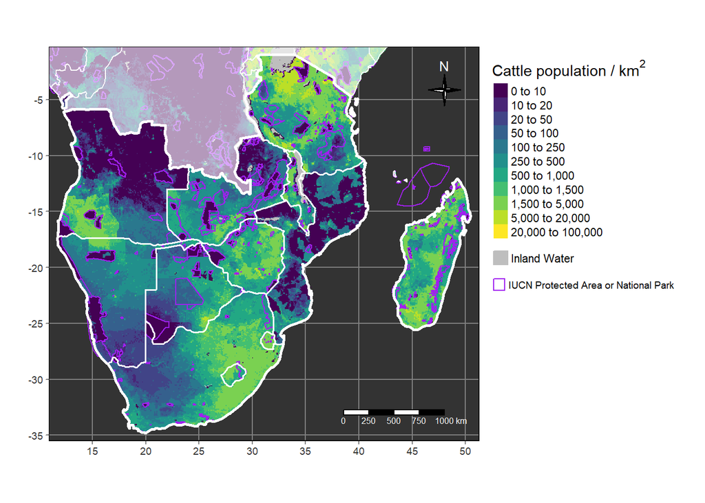

```r
pal_YlOrBr = c("#cccccc", brewer.pal(n = 9, name = "YlOrBr"))

plot_dens_Da = tm_shape(cattle_aoi) +
  tm_grid() +
  # tm_raster(palette = pal_YlOrBr,
  tm_raster(palette = "viridis",
            style = "fixed", title = expression("Cattle population / km"^2),
            breaks = c(0, 10, 20, 50, 100, 250, 500,  1000, 1500, 5000, 2*10^4, 10^5)) +
tm_shape(water_aoi) +
  tm_polygons(col = "grey", border.alpha = 0) +
tm_shape(pa_aoi_npark) +
  tm_borders(col = "purple") +
tm_shape(bord_naoi) +
  tm_polygons(col = "#ffffff", alpha = 0.6, border.col = "white") +
# tm_shape(hills_aoi) +
#   tm_raster(style = "cont", palette = "-Greys", stretch.palette = T, alpha = 0.4, legend.show = F) +
tm_shape(bord_aoi, is.master = T) +
  tm_borders(col = "white", lwd = 1.5) +
tm_shape(bord_aoi_union) +
  tm_borders(col = "white", lwd = 2.5) +
tm_compass(type = "4star", position = c("right", "top"), size = 2, text.color = "white") +
tm_scale_bar(breaks = seq(0, 1000, by = 250), position = c("right", "bottom"), text.color = "white") +
tm_add_legend(type = "fill", col = "grey", labels = "Inland Water", border.col = "grey") +
tm_add_legend(type = "symbol", col = "purple", labels = "IUCN Protected Area or National Park", shape = 0) +
tm_layout(legend.outside = T, bg.color = "#333333")

plot_dens_Da
```

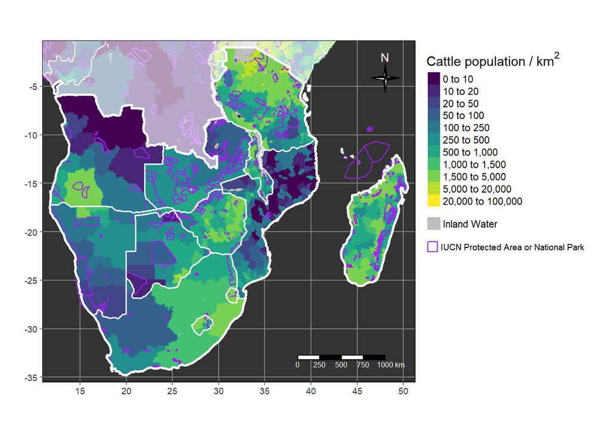

```r
plot_dens_Aw = tm_shape(cattle_aoi_aw) +
  tm_grid() +
  # tm_raster(palette = pal_YlOrBr,
  tm_raster(palette = "viridis",
            style = "fixed", title = expression("Cattle population / km"^2),
            breaks = c(0, 10, 20, 50, 100, 250, 500,  1000, 1500, 5000, 2*10^4, 10^5)) +
tm_shape(water_aoi) +
  tm_polygons(col = "grey", border.alpha = 0) +
tm_shape(pa_aoi_npark) +
  tm_borders(col = "purple") +
tm_shape(bord_naoi) +
  tm_polygons(col = "#ffffff", alpha = 0.6, border.col = "white") +
tm_shape(bord_aoi, is.master = T) +
  tm_borders(col = "white", lwd = 1.5) +
tm_shape(bord_aoi_union) +
  tm_borders(col = "white", lwd = 2.5) +
tm_compass(type = "4star", position = c("right", "top"), size = 2, text.color = "white") +
tm_scale_bar(breaks = seq(0, 1000, by = 250), position = c("right", "bottom"), text.color = "white") +
tm_add_legend(type = "fill", col = "grey", labels = "Inland Water", border.col = "grey") +
tm_add_legend(type = "symbol", col = "purple", labels = "IUCN Protected Area or National Park", shape = 0) +
tm_layout(legend.outside = T, bg.color = "#333333")

plot_dens_Aw
```

### Process potentially useful ancillary data

To get some context to the region, there are a number of potentially useful datasets that we could use. For example, what is the climate like (past/future)? Where are the people? How remote are the different parts of the region? Where are the protected areas?

To start, I’ve downloaded the climate data. The below code chunk is perhaps overkill on the data extraction. I’ve downloaded all the historical bioclim variables and the RCP 4.5 and 8.5 simulations for 2070 at 5 min resolution. It’s set up to download the future simulations from all the models, but not all models are available. That’s probably for the best. We got from model “AC” to “CE” 4.5. There is no CE 8.5 for 2070, so the loop collapsed. In hindsight, that’s a good thing as I don’t need all that data! Also, the entire global prediction is downloaded in each instance (~50MB each) before being cropped to the AOI and saved again. Definitely overkill.

```r
worldclim_aoi = getData("worldclim", var = "bio", res = 5) %>% crop(bound_aoi)

writeRaster(worldclim_aoi, filename = "Data/WorldClim/H4H_WorldClim.tif", bylayer = T, suffix = "names", overwrite = T)


cmip5_models = c("AC", "BC", "CC", "CE", "CN", "GF", "GD", "GS", "HD", "HG", "HE", "IN", "IP", "MI", "MR", "MC", "MP", "MG", "NO")
cmip5_rcps = c(45, 85)

for(mod in 1:length(cmip5_models)){
  for(rcp in 1:2){
cmip5_aoi = getData("CMIP5", var = "bio", res = 5, model = cmip5_models[mod], rcp = cmip5_rcps[rcp], year =70) %>% crop(bound_aoi)
writeRaster(cmip5_aoi, filename = "Data/CMIP5/H4H_CMIP5.tif", bylayer = T, suffix = "names", overwrite = T)
  }
}
```

```r
bioclim_detail = read_csv("Data/WorldClim/bioclim_codes.csv")

bioclim_voi = paste0("bio", c(1,4,5,10,12,14,15,16))


# WoldClim (Historical)
path_worldclim = list.files(paste0("Data/WorldClim"),
           pattern = ".tif",
           all.files = T, full.names = T)

df_worldclim_voi = tibble(path = path_worldclim) %>%
  mutate(bioclim = path %>%
           str_extract("(?<=Clim_).+") %>%
           str_extract(".+(?=.tif)"),
         incl = bioclim %in% bioclim_voi) %>%
  filter(incl == T) %>%
  left_join(bioclim_detail, by = "bioclim")

stack_worldclim_aoi = stack(df_worldclim_voi$path)
names(stack_worldclim_aoi) = df_worldclim_voi$bioclim

# CMIP 5 (Projection)
path_cmip5 = list.files(paste0("Data/CMIP5"),
           pattern = "CMIP5_ac",
           all.files = T, full.names = T)

df_cmip5_voi = tibble(path = path_cmip5) %>%
  mutate(summary = path %>%
           str_extract("(?<=CMIP5_).+") %>%
           str_extract(".+(?=.tif)"),
         bioclim = paste0("bio", str_sub(summary,start = 9)),
         rcp = str_sub(summary, start =3, end = 4),
         incl = bioclim %in% bioclim_voi) %>%
  filter(incl == T) %>%
  left_join(bioclim_detail, by = "bioclim")

df_cmip5_voi_45 = df_cmip5_voi %>% filter(rcp == "45")
df_cmip5_voi_85 = df_cmip5_voi %>% filter(rcp == "85")

stack_cmip545_aoi = stack(df_cmip5_voi_45$path)
stack_cmip585_aoi = stack(df_cmip5_voi_85$path)

names(stack_cmip545_aoi) = df_cmip5_voi_45$bioclim
names(stack_cmip585_aoi) = df_cmip5_voi_85$bioclim

# Combine them by bioclim and calc diff
list_stack_bioclim = list()
list_stack_diff = list()

for(i in 1:length(df_worldclim_voi$bioclim)){
list_stack_bioclim[[i]] = stack(stack_worldclim_aoi[[i]],
                           stack_cmip545_aoi[[i]],
                           stack_cmip585_aoi[[i]])
names(list_stack_bioclim[[i]]) = c("Hist", "RCP45", "RCP85")

list_stack_diff[[i]] = overlay(list_stack_bioclim[[i]]$RCP45, list_stack_bioclim[[i]]$Hist, fun=function(r1, r2){return(r1-r2)})
list_stack_diff[[i]]$diff_85 = overlay(list_stack_bioclim[[i]]$RCP85, list_stack_bioclim[[i]]$Hist, fun=function(r1, r2){return(r1-r2)})
names(list_stack_diff[[i]]) = c("diff_45", "diff_85")
}
names(list_stack_bioclim) = df_worldclim_voi$bioclim
names(list_stack_diff) = df_worldclim_voi$bioclim
```

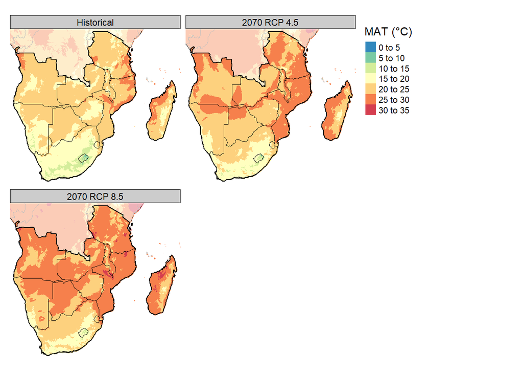

```r
breaks_mat = seq(50, 350, by = 50)
breaks_matdiff = seq(10, 55, by = 5)

plot_mat = tm_shape(list_stack_bioclim[[1]]) +
  tm_raster(style = "fixed", breaks = c(0, breaks_mat), title = "MAT (°C)", palette = "-Spectral", legend.format = list(fun = function(x) x/10)) +
tm_shape(bound_bord) +
  tm_borders(col = "black") +
tm_shape(bord_naoi) +
  tm_polygons(col = "#ffffff", alpha = 0.6, border.col = "grey") +
tm_shape(bord_aoi, is.master = T) +
  tm_borders(col = "black") +
tm_shape(bord_aoi_union) +
  tm_borders(col = "black", lwd = 1.5) +
tm_layout(panel.show = T, panel.labels = c("Historical", "2070 RCP 4.5", "2070 RCP 8.5"), legend.outside = T, frame = F)

plot_mat
```

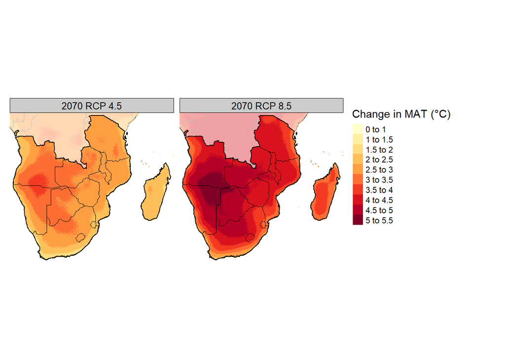

```r
plot_diffmat = tm_shape(list_stack_diff[[1]]) +
  tm_raster(style = "fixed", breaks = c(0, breaks_matdiff), title = "Change in MAT (°C)", palette = "YlOrRd", legend.format = list(fun = function(x) x/10)) +
tm_shape(bound_bord) +
  tm_borders(col = "black") +
tm_shape(bord_naoi) +
  tm_polygons(col = "#ffffff", alpha = 0.6, border.col = "grey") +
tm_shape(bord_aoi, is.master = T) +
  tm_borders(col = "black") +
tm_shape(bord_aoi_union) +
  tm_borders(col = "black", lwd = 1.5) +
tm_layout(panel.show = T, panel.labels = c("2070 RCP 4.5", "2070 RCP 8.5"), legend.outside = T, frame = F)

plot_diffmat
```

```r
# tmap_save(plot_mat, paste0("Output/", today, "Climate_", df_worldclim_voi$short[1],"_AOI.png"), width = 9, height = 3)
# tmap_save(plot_diffmat, paste0("Output/", today, "Climate_", df_worldclim_voi$short[1]," Change_AOI.png"), width = 9, height = 3)
```

```r
population_aoi = raster("Data/Accessibility/GPWv411_PopDens.tif")
population_aoi = setMinMax(population_aoi)
```

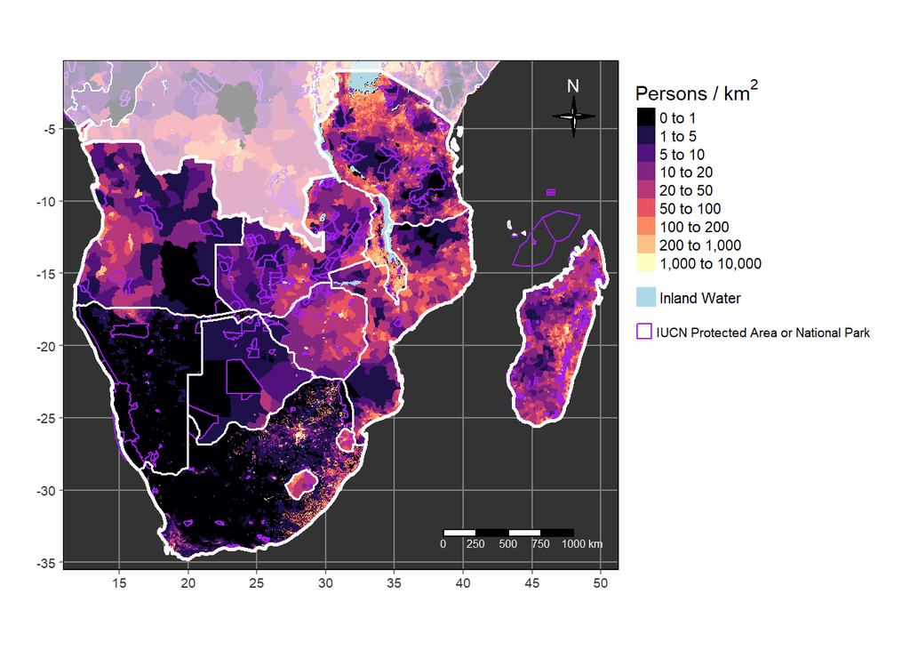

```r
plot_dens_Pop = tm_shape(bound_bord) +
  tm_grid() +
  tm_polygons(col = "black") +
tm_shape(population_aoi) +
  tm_raster(style = "fixed", breaks = c(0,1,5,10,20,50,100, 200, 1000, 10000), palette = "magma",
            legend.hist = F, title = expression("Persons / km"^2)) +
tm_shape(water_aoi) +
  tm_polygons(col = "lightblue", border.alpha = 0) +
tm_shape(pa_aoi_npark) +
  tm_borders(col = "purple") +
tm_shape(bord_naoi) +
  tm_polygons(col = "#ffffff", alpha = 0.6, border.col = "white") +
tm_shape(bord_aoi, is.master = T) +
  tm_borders(col = "white", lwd = 1.5) +
tm_shape(bord_aoi_union) +
  tm_borders(col = "white", lwd = 2.5) +
tm_compass(type = "4star", position = c("right", "top"), size = 2, text.color = "white") +
tm_scale_bar(breaks = seq(0, 1000, by = 250), position = c("right", "bottom"), text.color = "white") +
tm_add_legend(type = "fill", col = "lightblue", border.col = "lightblue", labels = "Inland Water") +
tm_add_legend(type = "symbol", col = "purple", labels = "IUCN Protected Area or National Park", shape = 0) +
tm_layout(legend.outside = T, bg.color = "#333333")

plot_dens_Pop
```

```r
access_aoi = raster("Data/Accessibility/Oxford_accessibility.tif")
access_aoi[access_aoi<1] <- NA
```

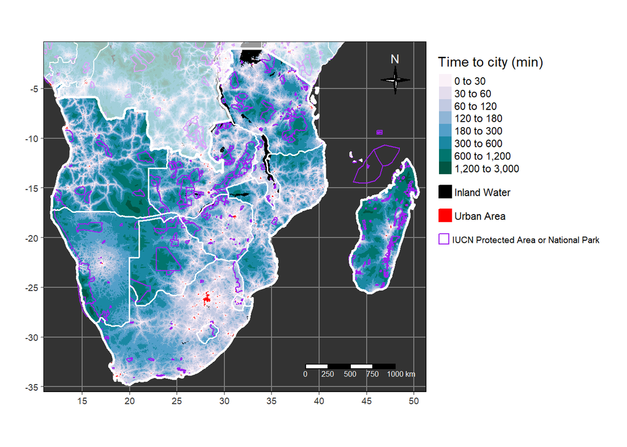

```r
plot_dens_Access = tm_shape(bound_bord) +
  tm_grid() +
  tm_polygons(col = "red") +
tm_shape(access_aoi) +
  tm_raster(style = "fixed", breaks = c(0,30,60,120,180,300,600,1200,3000),
            legend.hist = F, palette = "PuBuGn", title = "Time to city (min)") +
tm_shape(water_aoi) +
  tm_polygons(col = "black", border.alpha = 0) +
tm_shape(pa_aoi_npark) +
  tm_borders(col = "purple") +
tm_shape(bord_naoi) +
  tm_polygons(col = "#ffffff", alpha = 0.6, border.col = "white") +
tm_shape(bord_aoi, is.master = T) +
  tm_borders(col = "white", lwd = 1.5) +
tm_shape(bord_aoi_union) +
  tm_borders(col = "white", lwd = 2.5) +
tm_compass(type = "4star", position = c("right", "top"), size = 2, text.color = "white") +
tm_scale_bar(breaks = seq(0, 1000, by = 250), position = c("right", "bottom"), text.color = "white") +
tm_add_legend(type = "fill", col = "black", labels = "Inland Water", border.col = "black") +
tm_add_legend(type = "fill", col = "red", labels = "Urban Area", border.col = "red") +
tm_add_legend(type = "symbol", col = "purple", labels = "IUCN Protected Area or National Park", shape = 0) +
tm_layout(legend.outside = T, bg.color = "#333333")

# , border.col = "black"

plot_dens_Access
```

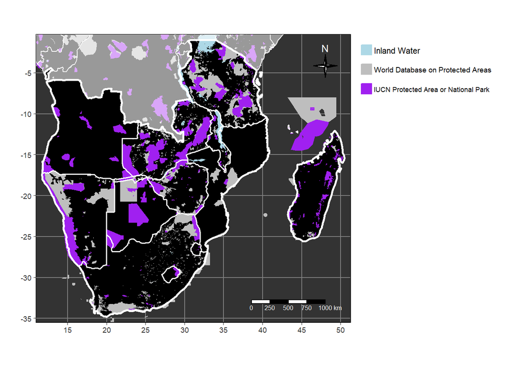

```r
plot_PAs = tm_shape(bound_bord) +
  tm_grid() +
  tm_polygons(col = "black") +
tm_shape(water_aoi) +
  tm_polygons(col = "lightblue", border.alpha = 0) +
tm_shape(pa_aoi) +
  tm_polygons(col = "grey", border.alpha = 0) +
tm_shape(pa_aoi_npark) +
  tm_polygons(col = "purple", border.alpha = 0) +
tm_shape(bord_naoi) +
  tm_polygons(col = "#ffffff", alpha = 0.6, border.col = "white") +
tm_shape(bord_aoi, is.master = T) +
  tm_borders(col = "white", lwd = 1.5) +
tm_shape(bord_aoi_union) +
  tm_borders(col = "white", lwd = 2.5) +
tm_compass(type = "4star", position = c("right", "top"), size = 2, text.color = "white") +
tm_scale_bar(breaks = seq(0, 1000, by = 250), position = c("right", "bottom"), text.color = "white") +
tm_add_legend(type = "fill", col = "lightblue", labels = "Inland Water", border.col = "lightblue") +
tm_add_legend(type = "fill", col = "grey", labels = "World Database on Protected Areas", border.col = "grey") +
tm_add_legend(type = "fill", col = "purple", labels = "IUCN Protected Area or National Park", border.col = "purple") +
tm_layout(legend.outside = T, bg.color = "#333333")

plot_PAs
```

```r
tmap_save(plot_dens_Da, paste0("Output/", today, "Cattle density distribution_AOI_Da.png"), width = 9, height = 6)
tmap_save(plot_dens_Aw, paste0("Output/", today, "Cattle density distribution_AOI_Aw.png"), width = 9, height = 6)
tmap_save(plot_dens_Pop, paste0("Output/", today, "Human population density_AOI.png"), width = 9, height = 6)
tmap_save(plot_dens_Access, paste0("Output/", today, "Time to city_AOI.png"), width = 9, height = 6)
tmap_save(plot_PAs, paste0("Output/", today, "Protected Areas_AOI.png"), width = 9, height = 6)
```